# The MMJMesh Library

Minh’s and Matthias’ Julia Mesh Library

Author

Matthias Baitsch

# 1 Introduction

The `MMJMesh` library is intended to become a simple yet versatile basis for the implementation of finite element methods or postprocessing tools. At the moment it is in a very early stage of development.

## 1.1 Demo for 1D meshes

First, we need to load the required modules. Note that `CairoMakie` included by `import` and not by `using` in order to avoid name collissions.

```julia
include("setup.jl")
```

```
meshpath (generic function with 1 method)
```

In the simplest case, a 1D mesh is defined by parameter bounds and the number of elements.

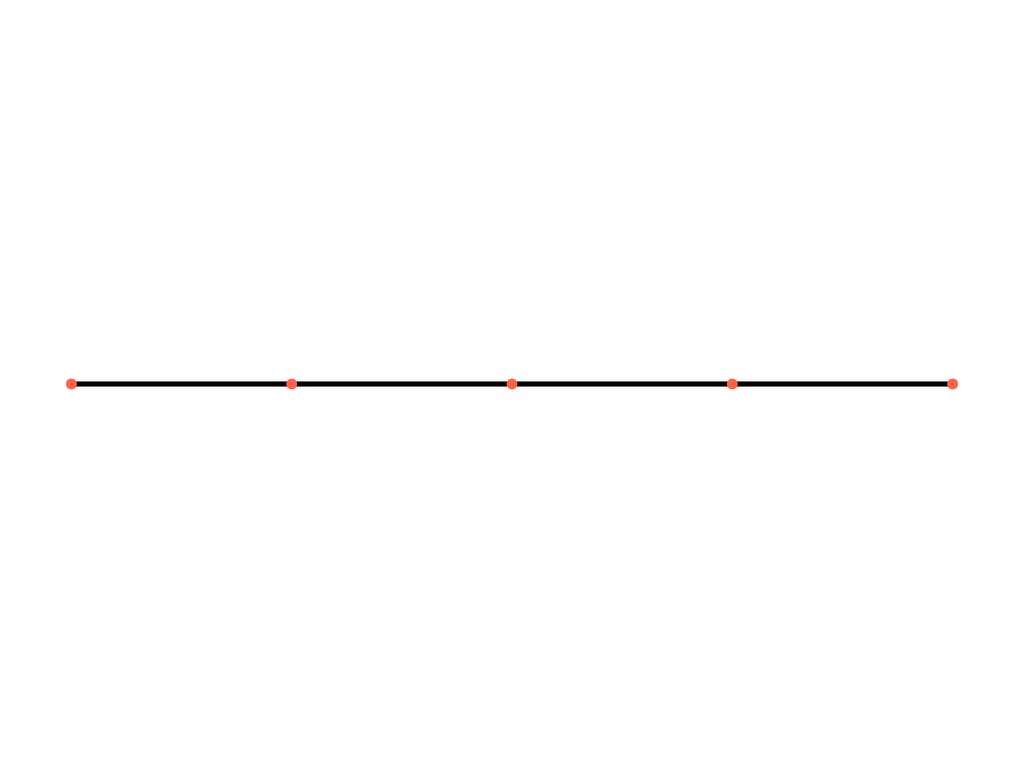

```julia
m = makemeshoninterval(0.0, 8.0, 4)
mplot(m) |> mconf()
```

Elements of the mesh can be easily processed in a loop:

```julia
for e ∈ elements(m)
    println(e, " with n = ", nodeindices(e), " and l = ", length(e))
end
```

```
Edge{2, 2, MMJMesh.Geometries.GeometricObjectI}[1] with n = [1, 2] and l = 2.0
Edge{2, 2, MMJMesh.Geometries.GeometricObjectI}[2] with n = [2, 3] and l = 2.0
Edge{2, 2, MMJMesh.Geometries.GeometricObjectI}[3] with n = [3, 4] and l = 2.0
Edge{2, 2, MMJMesh.Geometries.GeometricObjectI}[4] with n = [4, 5] and l = 2.0
```

Various functions like `nodeindices` and `length` exist to access properties. If you are used to an object-oriented language like Java it might be helpful to understand that `nodeindices(e)` in Julia is equivalent to `e.nodeindices()` in an OO language.

Node coordinates are retrieved using the `coordinates` method:

```julia
coordinates(m)
```

```
2×5 Matrix{Float64}:
 0.0  2.0  4.0  6.0  8.0
 0.0  0.0  0.0  0.0  0.0
```

Properties are associated with the mesh using the `data` field of the mesh and a name for the property in the form `:name`

```julia
m.data[:foo] = 99
m.data[:bar] = sqrt;
```

and then are ready to be used in a later stage

```julia
f = m.data[:bar]
f(4)
```

```
2.0
```

In Julia, `:name` is called a symbol. In many applications, this is equivalent to the use of strings like `"name"`, however, easier to type.

It is easy to plot quantities for nodes

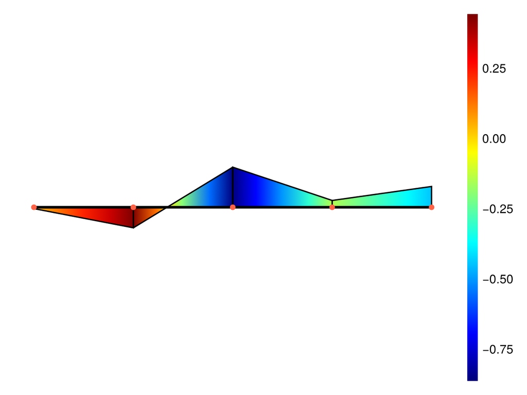

```julia
mplot(m, -1 .+ 2 * rand(nnodes(m))) |> mconf()
```

constant on elements

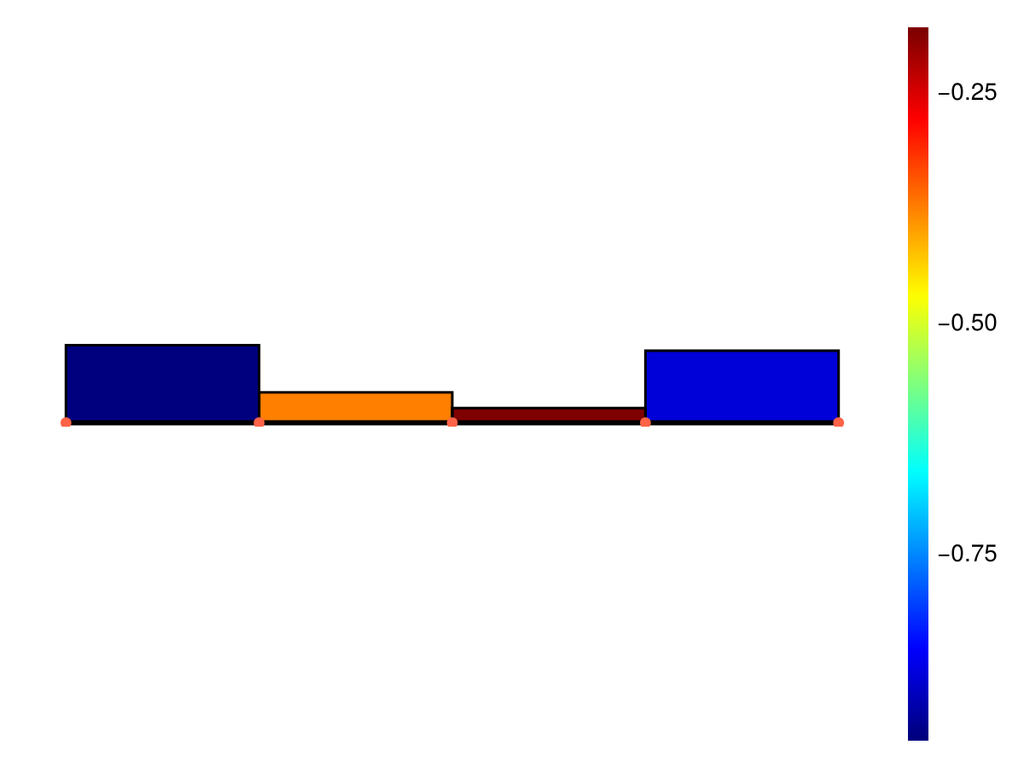

```julia
mplot(m, -1 .+ 2 * rand(nelements(m))) |> mconf()
```

linear on elements

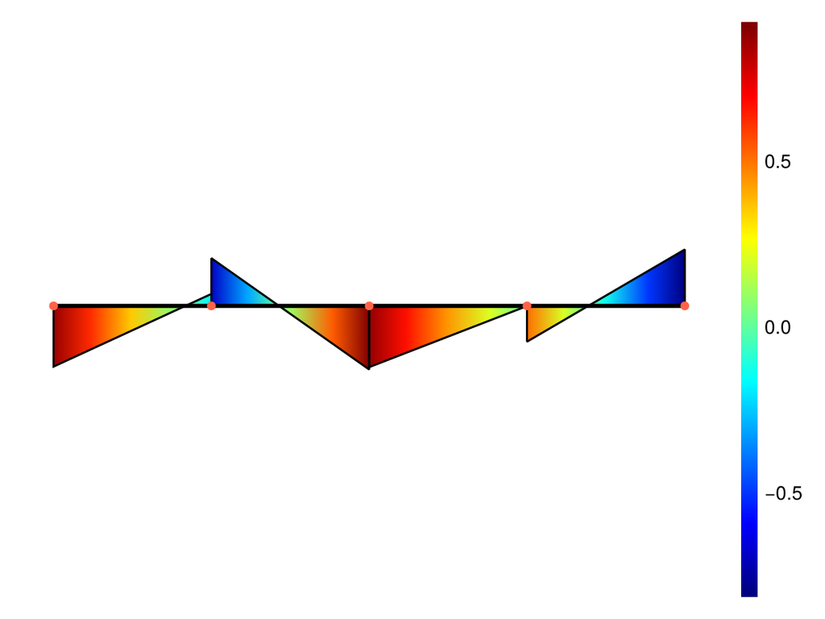

```julia
mplot(m, -1 .+ 2 * rand(2, nelements(m))) |> mconf()
```

functions on elements

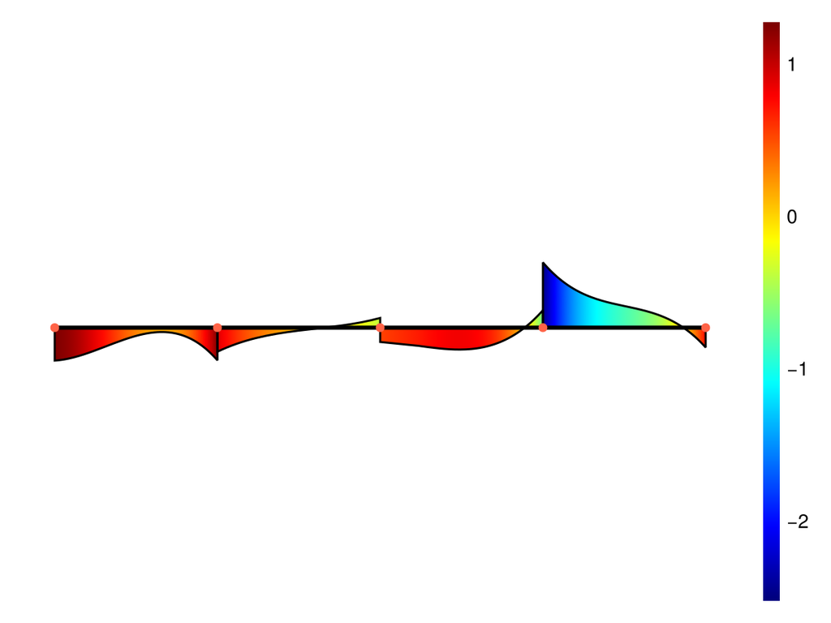

```julia
mplot(m, [Polynomial(rand(-1 .. 1, 4), IHat) for _ ∈ 1:nelements(m)]) |> mconf()
```

Furthermore, 1D meshes can be created with a parametric function

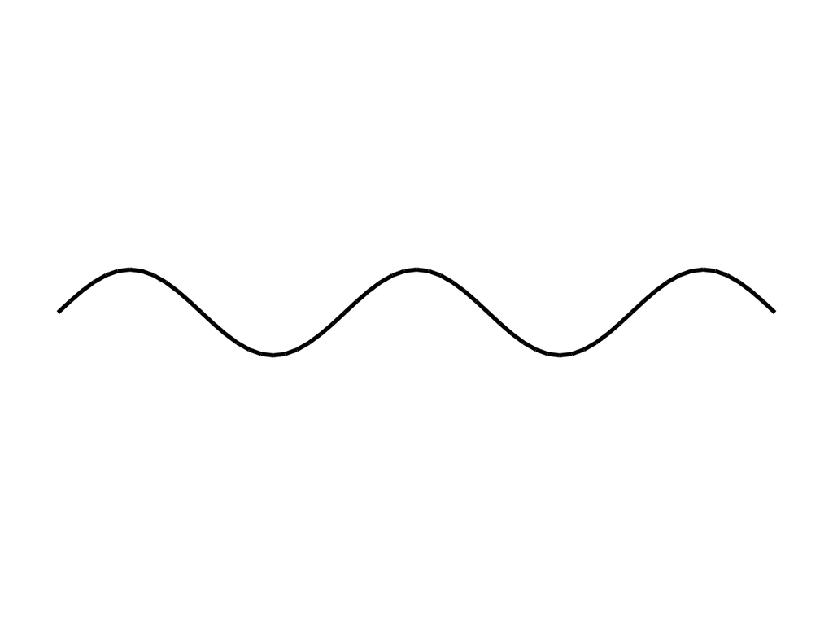

```julia
m = makemeshoninterval(0, 5, 60, t -> [t; 0.3 * sin(π * t)])
mplot(m) |> mconf()
```

## 1.2 Demo for 2D meshes

Create mesh on rectangular grid

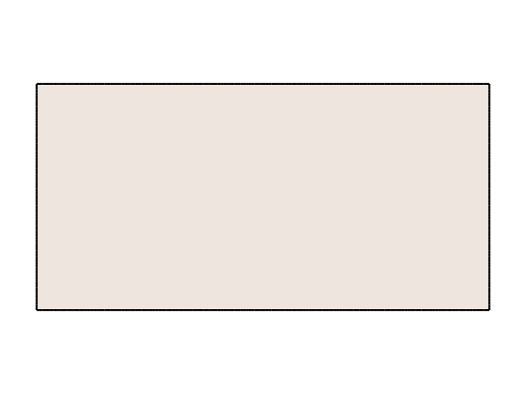

```julia
a = 80
m = makemeshonrectangle(9.0, 4.5, 2a, a)
mplot(m) |> mconf()
```

Mesh with coordinate transformation

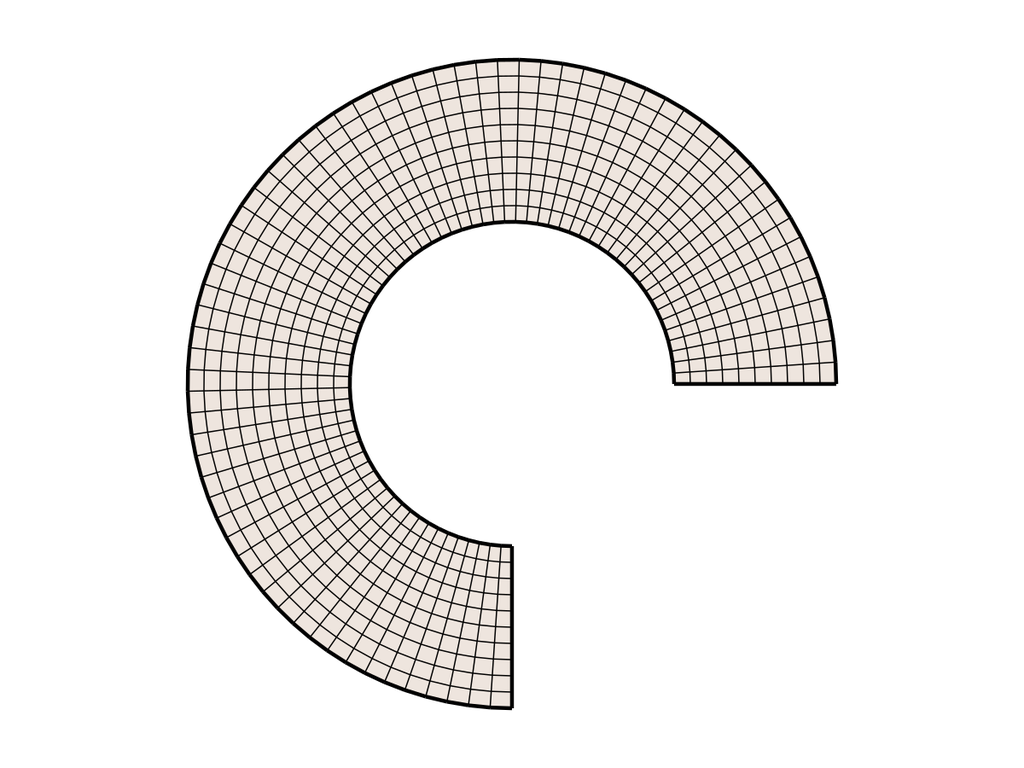

```julia
cartesianfrompolar(x) = x[1] * [cos(x[2]), sin(x[2])]
m = makemeshonrectangle((1 .. 2) × (0 .. (3 / 2)π), 10, 70, gmap=cartesianfrompolar)
mplot(m, edgesvisible=true) |> mconf()
```

Read mesh from Gmsh

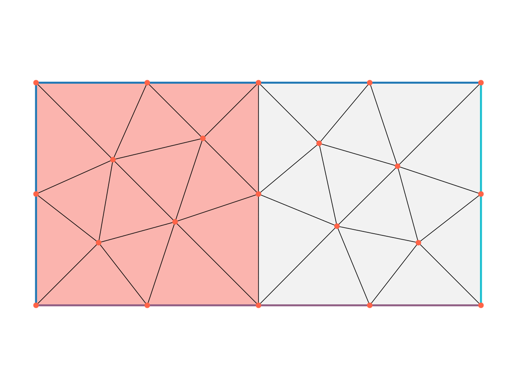

```julia
m = Mesh(meshpath("advanced.msh"))
mplot(m) |> mconf()
```

Indices of nodes on boundary

```julia
m.groups[:boundarynodes]
```

```
12-element NodeGroup:
  1
  2
  3
  4
  5
  6
  7
  9
 10
 11
 12
 13
```